# DEI Commitment Update Study: Technical Appendix

Casey McMahon

2026-05-14

# Overview

This appendix reports the main analyses in finer detail for the DEI commitment update study. Participants first read an initial DEI commitment and then read an update in which the organization either rolled back the commitment, maintained the original commitment, or doubled down on the commitment. The main question was whether organizational backtracking increased perceived hypocrisy and reduced perceptions of organizational credibility.

```r
data <- readr::read_csv("data/dei-rollback-update-cleaned.csv")

# Use the binary-gender dataset only if needed for sensitivity checks.
# data <- readr::read_rds("data/dei-rollback-update-cleaned-binary-gender.rds")
```

# Helper functions

```r
format_num <- function(x, digits = 2) {
  dplyr::if_else(
    is.na(x),
    "",
    sprintf(paste0("%.", digits, "f"), x)
  )
}

format_p_text <- function(p) {
  dplyr::case_when(
    is.na(p) ~ "",
    p < .001 ~ "< .001",
    TRUE ~ sprintf("%.3f", p)
  )
}

clean_kable <- function(df, caption = NULL, align = NULL, escape = FALSE) {
  kableExtra::kable(
    df,
    format = "html",
    caption = caption,
    align = align,
    escape = escape
  ) %>%
    kableExtra::kable_styling(
      full_width = FALSE,
      position = "center",
      bootstrap_options = c("striped", "hover", "condensed")
    )
}

#changing the reference group
data <- data %>%
  dplyr::mutate(
    condition_label = factor(
      condition_label,
      levels = c(
        "Rollback",
        "Maintained commitment",
        "Doubled down"
      )
    )
  )

clean_lm_table <- function(model, caption = NULL) {
  broom::tidy(model) %>%
    dplyr::mutate(
      Predictor = dplyr::case_when(
        term == "(Intercept)" ~ "Intercept",
        term == "condition_labelMaintained commitment" ~ "Condition: maintained commitment",
        term == "condition_labelDoubled down" ~ "Condition: doubled down",
        term == "race_simplePeople of color" ~ "Participant race: people of color",
        term == "gender_labelWomen" ~ "Participant gender: women",
        term == "gender_labelMen" ~ "Participant gender: men",
        term == "age" ~ "Age",
        TRUE ~ term
      ),
      b = sprintf("%.2f", estimate),
      SE = sprintf("%.2f", std.error),
      t = sprintf("%.2f", statistic),
      p = format_p_text(p.value)
    ) %>%
    dplyr::select(Predictor, b, SE, t, p) %>%
    clean_kable(caption = caption, align = c("l", "c", "c", "c", "c"), escape = TRUE)
}

make_alpha <- function(df, vars) {
  psych::alpha(df %>% dplyr::select(dplyr::all_of(vars)), check.keys = TRUE)$total$raw_alpha
}

make_descriptive_table <- function(df, outcome_vars, labels, group_var = condition_label) {
  df %>%
    dplyr::select({{ group_var }}, dplyr::all_of(outcome_vars)) %>%
    tidyr::pivot_longer(
      cols = dplyr::all_of(outcome_vars),
      names_to = "outcome",
      values_to = "value"
    ) %>%
    dplyr::group_by({{ group_var }}, outcome) %>%
    dplyr::summarise(
      N = sum(!is.na(value)),
      M = mean(value, na.rm = TRUE),
      SD = sd(value, na.rm = TRUE),
      .groups = "drop"
    ) %>%
    dplyr::mutate(
      outcome = dplyr::recode(outcome, !!!labels),
      M = sprintf("%.2f", M),
      SD = sprintf("%.2f", SD)
    ) %>%
    dplyr::rename(
      Condition = {{ group_var }},
      Outcome = outcome
    )
}

format_p_html <- function(p) {
  dplyr::case_when(
    is.na(p) ~ "",
    p < .001 ~ "&lt; .001",
    TRUE ~ sprintf("%.3f", p)
  )
}

make_emmeans_table <- function(model, caption = NULL) {
  emm <- emmeans::emmeans(model, ~ condition_label)

  pairwise <- emmeans::contrast(
    emm,
    method = "pairwise"
  ) %>%
    summary(adjust = "tukey") %>%
    as.data.frame() %>%
    dplyr::mutate(
      p_clean = format_p_html(p.value),
      contrast = stringr::str_replace_all(contrast, " - ", " − ")
    ) %>%
    dplyr::select(
      Contrast = contrast,
      b = estimate,
      SE,
      df,
      t = t.ratio,
      p = p_clean
    ) %>%
    dplyr::mutate(
      b = sprintf("%.2f", b),
      SE = sprintf("%.2f", SE),
      df = sprintf("%.1f", df),
      t = sprintf("%.2f", t)
    )

  clean_kable(pairwise, caption = caption)
}
```

# Sample and data checks

The tables below summarize the analytic sample after exclusions and attention checks.

Participants by condition

| Condition | N | Percent |
| --- | --- | --- |
| Rollback | 160 | 34.8% |
| Maintained commitment | 147 | 32.0% |
| Doubled down | 153 | 33.3% |

Participant race/ethnicity

| Race/ethnicity | N | Percent |
| --- | --- | --- |
| Another race | 1 | 0.2% |
| Asian | 28 | 6.1% |
| Bi/multiracial | 22 | 4.8% |
| Black | 81 | 17.6% |
| Hispanic | 19 | 4.1% |
| Middle Eastern | 6 | 1.3% |
| Native American | 1 | 0.2% |
| White | 302 | 65.7% |

Participant gender

| Gender | N | Percent |
| --- | --- | --- |
| Another gender | 8 | 1.7% |
| Men | 190 | 41.3% |
| Non-binary | 2 | 0.4% |
| Women | 260 | 56.5% |

Participant age

| N | M | SD | Min | Max |
| --- | --- | --- | --- | --- |
| 458 | 39.49 | 12.86 | 18 | 79 |

# Measures and scale reliability

Scale reliability

| Scale | Cronbach’s alpha |
| --- | --- |
| Hypocrisy at Time 1 | 0.90 |
| Genuineness at Time 1 | 0.89 |
| Anticipated belonging at Time 1 | 0.97 |
| Hypocrisy at Time 2 | 0.97 |
| Anticipated belonging at Time 2 | 0.98 |
| Expectation violation | 0.95 |
| False signaling | 0.93 |

# Descriptive results by condition

Note: The key comparison is whether the rollback condition produced higher hypocrisy and lower credibility than maintaining or doubling down on the original DEI commitment.

Descriptive statistics by condition, M (SD)

| Outcome | Rollback | Maintained commitment | Doubled down |
| --- | --- | --- | --- |
| Anticipated belonging | 3.48 (1.63) | 4.81 (1.76) | 4.79 (1.73) |
| Expectation violation | 4.80 (1.58) | 2.72 (1.43) | 2.77 (1.38) |
| False signaling | 4.79 (1.46) | 3.04 (1.50) | 2.83 (1.50) |
| Hypocrisy | 5.12 (1.56) | 2.32 (1.26) | 2.32 (1.35) |
| Company impression | 2.49 (1.01) | 3.71 (1.06) | 3.75 (1.09) |
| Recommendation likelihood | 3.05 (1.65) | 5.29 (1.65) | 5.20 (1.73) |

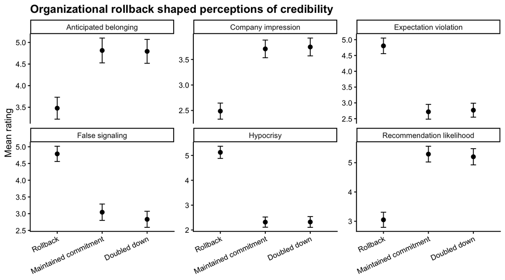

```r
ggsave(
  filename = "../assets/img/dei-rollback-update-outcomes.png",
  plot = rollback_update_outcomes_plot,
  width = 9,
  height = 5,
  dpi = 300
)
```

# Main condition models

The models below test whether the commitment-update condition predicted the key Time 2 outcomes. (The rollback condition is the reference group, so positive or negative coefficients for the other conditions indicate how maintaining or doubling down differed from rollback.)

Condition model predicting hypocrisy

| Predictor | b | SE | t | p |
| --- | --- | --- | --- | --- |
| Intercept | 5.12 | 0.11 | 46.18 | < .001 |
| Condition: maintained commitment | -2.81 | 0.16 | -17.50 | < .001 |
| Condition: doubled down | -2.80 | 0.16 | -17.65 | < .001 |

Condition model predicting company impressions

| Predictor | b | SE | t | p |
| --- | --- | --- | --- | --- |
| Intercept | 2.49 | 0.08 | 29.86 | < .001 |
| Condition: maintained commitment | 1.22 | 0.12 | 10.13 | < .001 |
| Condition: doubled down | 1.26 | 0.12 | 10.55 | < .001 |

Condition model predicting anticipated belonging

| Predictor | b | SE | t | p |
| --- | --- | --- | --- | --- |
| Intercept | 3.48 | 0.13 | 25.80 | < .001 |
| Condition: maintained commitment | 1.34 | 0.19 | 6.86 | < .001 |
| Condition: doubled down | 1.32 | 0.19 | 6.82 | < .001 |

Condition model predicting expectation violation

| Predictor | b | SE | t | p |
| --- | --- | --- | --- | --- |
| Intercept | 4.80 | 0.12 | 41.42 | < .001 |
| Condition: maintained commitment | -2.09 | 0.17 | -12.44 | < .001 |
| Condition: doubled down | -2.04 | 0.17 | -12.27 | < .001 |

Condition model predicting false signaling

| Predictor | b | SE | t | p |
| --- | --- | --- | --- | --- |
| Intercept | 4.79 | 0.12 | 40.74 | < .001 |
| Condition: maintained commitment | -1.74 | 0.17 | -10.26 | < .001 |
| Condition: doubled down | -1.96 | 0.17 | -11.64 | < .001 |

Condition model predicting recommendation likelihood

| Predictor | b | SE | t | p |
| --- | --- | --- | --- | --- |
| Intercept | 3.05 | 0.13 | 22.99 | < .001 |
| Condition: maintained commitment | 2.24 | 0.19 | 11.70 | < .001 |
| Condition: doubled down | 2.15 | 0.19 | 11.35 | < .001 |

# Post hoc condition comparisons

The post hoc tests compare the three commitment-update conditions directly to one another.

Post hoc comparisons for hypocrisy

| Contrast | b | SE | df | t | p |
| --- | --- | --- | --- | --- | --- |
| Rollback − Maintained commitment | 2.81 | 0.16 | 457.0 | 17.50 | < .001 |
| Rollback − Doubled down | 2.80 | 0.16 | 457.0 | 17.65 | < .001 |
| Maintained commitment − Doubled down | -0.01 | 0.16 | 457.0 | -0.04 | 0.999 |

Post hoc comparisons for company impressions

| Contrast | b | SE | df | t | p |
| --- | --- | --- | --- | --- | --- |
| Rollback − Maintained commitment | -1.22 | 0.12 | 457.0 | -10.13 | < .001 |
| Rollback − Doubled down | -1.26 | 0.12 | 457.0 | -10.55 | < .001 |
| Maintained commitment − Doubled down | -0.04 | 0.12 | 457.0 | -0.31 | 0.949 |

Post hoc comparisons for anticipated belonging

| Contrast | b | SE | df | t | p |
| --- | --- | --- | --- | --- | --- |
| Rollback − Maintained commitment | -1.34 | 0.19 | 457.0 | -6.86 | < .001 |
| Rollback − Doubled down | -1.32 | 0.19 | 457.0 | -6.82 | < .001 |
| Maintained commitment − Doubled down | 0.02 | 0.20 | 457.0 | 0.10 | 0.994 |

Post hoc comparisons for expectation violation

| Contrast | b | SE | df | t | p |
| --- | --- | --- | --- | --- | --- |
| Rollback − Maintained commitment | 2.09 | 0.17 | 457.0 | 12.44 | < .001 |
| Rollback − Doubled down | 2.04 | 0.17 | 457.0 | 12.27 | < .001 |
| Maintained commitment − Doubled down | -0.05 | 0.17 | 457.0 | -0.30 | 0.953 |

Post hoc comparisons for false signaling

| Contrast | b | SE | df | t | p |
| --- | --- | --- | --- | --- | --- |
| Rollback − Maintained commitment | 1.74 | 0.17 | 457.0 | 10.26 | < .001 |
| Rollback − Doubled down | 1.96 | 0.17 | 457.0 | 11.64 | < .001 |
| Maintained commitment − Doubled down | 0.21 | 0.17 | 457.0 | 1.24 | 0.431 |

Post hoc comparisons for recommendation likelihood

| Contrast | b | SE | df | t | p |
| --- | --- | --- | --- | --- | --- |
| Rollback − Maintained commitment | -2.24 | 0.19 | 457.0 | -11.70 | < .001 |
| Rollback − Doubled down | -2.15 | 0.19 | 457.0 | -11.35 | < .001 |
| Maintained commitment − Doubled down | 0.09 | 0.19 | 457.0 | 0.46 | 0.888 |